# ACM - TD

Dans ce TD, nous aborderons la réalisation de l’ACM sous R. Vous devez exécuter l’ensemble des commandes réalisées ici (et les comprendre), afin de pouvoir les reproduire.

En plus des packages présentés ci-dessous, nous devrons utiliser d’autres packages (inclus dans le chargement du package `tidyverse`) pour réaliser les graphiques et autres tableaux.

```r
library(tidyverse)
# library(stringr)
library(formattable)
```

## Package `FactoMiner`

Nous utilisons encore le package [`FactoMineR`](http://factominer.free.fr/) pour réaliser les calculs de l’ACM.

### Données `poison`

Nous allons utiliser le jeu de données [`poison`](https://rdrr.io/cran/FactoMineR/man/poison.html). Celui-ci concerne une étude sur une intoxication alimentaire d’enfants dans une école.

```r
library(FactoMineR)
data(poison)
```

| Age | Time | Sick | Sex | Nausea | Vomiting | Abdominals | Fever | Diarrhae | Potato | Fish | Mayo | Courgette | Cheese | Icecream |
| --- | --- | --- | --- | --- | --- | --- | --- | --- | --- | --- | --- | --- | --- | --- |
| 9 | 22 | Sick_y | F | Nausea_y | Vomit_n | Abdo_y | Fever_y | Diarrhea_y | Potato_y | Fish_y | Mayo_y | Courg_y | Cheese_y | Icecream_y |
| 5 | 0 | Sick_n | F | Nausea_n | Vomit_n | Abdo_n | Fever_n | Diarrhea_n | Potato_y | Fish_y | Mayo_y | Courg_y | Cheese_n | Icecream_y |
| 6 | 16 | Sick_y | F | Nausea_n | Vomit_y | Abdo_y | Fever_y | Diarrhea_y | Potato_y | Fish_y | Mayo_y | Courg_y | Cheese_y | Icecream_y |
| 9 | 0 | Sick_n | F | Nausea_n | Vomit_n | Abdo_n | Fever_n | Diarrhea_n | Potato_y | Fish_y | Mayo_n | Courg_y | Cheese_y | Icecream_y |
| 7 | 14 | Sick_y | M | Nausea_n | Vomit_y | Abdo_y | Fever_y | Diarrhea_y | Potato_y | Fish_y | Mayo_y | Courg_y | Cheese_y | Icecream_y |
| 72 | 9 | Sick_y | M | Nausea_n | Vomit_n | Abdo_y | Fever_y | Diarrhea_y | Potato_y | Fish_n | Mayo_y | Courg_y | Cheese_y | Icecream_y |
| 5 | 16 | Sick_y | F | Nausea_n | Vomit_y | Abdo_y | Fever_y | Diarrhea_y | Potato_y | Fish_y | Mayo_y | Courg_y | Cheese_y | Icecream_y |
| 10 | 8 | Sick_y | F | Nausea_y | Vomit_y | Abdo_y | Fever_y | Diarrhea_y | Potato_y | Fish_y | Mayo_y | Courg_y | Cheese_y | Icecream_y |
| 5 | 20 | Sick_y | M | Nausea_y | Vomit_n | Abdo_y | Fever_y | Diarrhea_y | Potato_y | Fish_y | Mayo_y | Courg_y | Cheese_y | Icecream_y |
| 11 | 12 | Sick_y | M | Nausea_n | Vomit_y | Abdo_n | Fever_y | Diarrhea_y | Potato_y | Fish_y | Mayo_y | Courg_y | Cheese_y | Icecream_y |
| 7 | 17 | Sick_y | F | Nausea_y | Vomit_y | Abdo_y | Fever_y | Diarrhea_y | Potato_y | Fish_y | Mayo_y | Courg_y | Cheese_y | Icecream_y |
| 10 | 16 | Sick_y | F | Nausea_n | Vomit_y | Abdo_y | Fever_n | Diarrhea_n | Potato_y | Fish_y | Mayo_y | Courg_y | Cheese_y | Icecream_y |
| 36 | 19 | Sick_y | F | Nausea_n | Vomit_n | Abdo_y | Fever_y | Diarrhea_y | Potato_y | Fish_y | Mayo_y | Courg_y | Cheese_y | Icecream_y |
| 9 | 0 | Sick_n | F | Nausea_n | Vomit_n | Abdo_n | Fever_n | Diarrhea_n | Potato_y | Fish_y | Mayo_n | Courg_y | Cheese_y | Icecream_y |
| 8 | 0 | Sick_n | M | Nausea_n | Vomit_n | Abdo_n | Fever_n | Diarrhea_n | Potato_y | Fish_y | Mayo_n | Courg_y | Cheese_n | Icecream_y |
| 6 | 6 | Sick_y | F | Nausea_n | Vomit_y | Abdo_y | Fever_y | Diarrhea_y | Potato_y | Fish_y | Mayo_y | Courg_y | Cheese_y | Icecream_y |
| 7 | 10 | Sick_y | M | Nausea_n | Vomit_y | Abdo_y | Fever_y | Diarrhea_y | Potato_y | Fish_y | Mayo_y | Courg_y | Cheese_n | Icecream_y |
| 5 | 15 | Sick_y | M | Nausea_y | Vomit_y | Abdo_y | Fever_y | Diarrhea_y | Potato_y | Fish_y | Mayo_y | Courg_y | Cheese_y | Icecream_y |
| 11 | 14 | Sick_y | F | Nausea_n | Vomit_y | Abdo_y | Fever_y | Diarrhea_y | Potato_y | Fish_y | Mayo_y | Courg_y | Cheese_y | Icecream_y |
| 11 | 0 | Sick_n | F | Nausea_n | Vomit_n | Abdo_n | Fever_n | Diarrhea_n | Potato_y | Fish_y | Mayo_n | Courg_y | Cheese_y | Icecream_y |
| 10 | 18 | Sick_y | M | Nausea_n | Vomit_n | Abdo_y | Fever_y | Diarrhea_y | Potato_y | Fish_y | Mayo_y | Courg_y | Cheese_y | Icecream_y |
| 8 | 14 | Sick_y | F | Nausea_n | Vomit_n | Abdo_y | Fever_y | Diarrhea_y | Potato_y | Fish_y | Mayo_y | Courg_y | Cheese_y | Icecream_n |
| 8 | 21 | Sick_y | F | Nausea_n | Vomit_y | Abdo_y | Fever_y | Diarrhea_y | Potato_y | Fish_y | Mayo_y | Courg_n | Cheese_y | Icecream_y |
| 11 | 13 | Sick_y | M | Nausea_n | Vomit_y | Abdo_y | Fever_n | Diarrhea_y | Potato_y | Fish_y | Mayo_y | Courg_y | Cheese_y | Icecream_y |
| 45 | 10 | Sick_y | F | Nausea_n | Vomit_n | Abdo_y | Fever_y | Diarrhea_y | Potato_y | Fish_y | Mayo_y | Courg_y | Cheese_n | Icecream_y |
| 9 | 0 | Sick_n | M | Nausea_n | Vomit_n | Abdo_n | Fever_n | Diarrhea_n | Potato_y | Fish_y | Mayo_y | Courg_y | Cheese_y | Icecream_y |
| 5 | 12 | Sick_y | F | Nausea_n | Vomit_y | Abdo_y | Fever_y | Diarrhea_n | Potato_y | Fish_y | Mayo_y | Courg_y | Cheese_y | Icecream_y |
| 85 | 9 | Sick_y | M | Nausea_n | Vomit_y | Abdo_y | Fever_y | Diarrhea_y | Potato_y | Fish_y | Mayo_n | Courg_n | Cheese_y | Icecream_y |
| 88 | 0 | Sick_n | F | Nausea_n | Vomit_n | Abdo_n | Fever_n | Diarrhea_n | Potato_y | Fish_y | Mayo_y | Courg_y | Cheese_y | Icecream_y |
| 79 | 17 | Sick_y | F | Nausea_y | Vomit_y | Abdo_y | Fever_y | Diarrhea_y | Potato_y | Fish_y | Mayo_y | Courg_y | Cheese_y | Icecream_y |
| 9 | 9 | Sick_y | F | Nausea_n | Vomit_n | Abdo_y | Fever_y | Diarrhea_y | Potato_y | Fish_y | Mayo_n | Courg_y | Cheese_y | Icecream_y |
| 6 | 0 | Sick_n | M | Nausea_n | Vomit_n | Abdo_n | Fever_n | Diarrhea_n | Potato_y | Fish_y | Mayo_n | Courg_y | Cheese_n | Icecream_y |
| 8 | 0 | Sick_n | F | Nausea_n | Vomit_n | Abdo_n | Fever_n | Diarrhea_n | Potato_y | Fish_y | Mayo_y | Courg_y | Cheese_y | Icecream_y |
| 8 | 0 | Sick_n | M | Nausea_n | Vomit_n | Abdo_n | Fever_n | Diarrhea_n | Potato_y | Fish_y | Mayo_y | Courg_y | Cheese_y | Icecream_y |
| 7 | 15 | Sick_y | F | Nausea_y | Vomit_n | Abdo_y | Fever_y | Diarrhea_y | Potato_n | Fish_y | Mayo_y | Courg_y | Cheese_y | Icecream_y |
| 9 | 19 | Sick_y | M | Nausea_y | Vomit_y | Abdo_y | Fever_y | Diarrhea_y | Potato_y | Fish_y | Mayo_y | Courg_y | Cheese_y | Icecream_y |
| 9 | 11 | Sick_y | M | Nausea_y | Vomit_n | Abdo_y | Fever_n | Diarrhea_y | Potato_n | Fish_y | Mayo_y | Courg_y | Cheese_y | Icecream_y |
| 6 | 0 | Sick_n | F | Nausea_n | Vomit_n | Abdo_n | Fever_n | Diarrhea_n | Potato_y | Fish_y | Mayo_y | Courg_n | Cheese_n | Icecream_y |
| 5 | 17 | Sick_y | M | Nausea_n | Vomit_n | Abdo_y | Fever_y | Diarrhea_y | Potato_n | Fish_y | Mayo_y | Courg_y | Cheese_y | Icecream_y |
| 6 | 16 | Sick_y | M | Nausea_y | Vomit_y | Abdo_y | Fever_y | Diarrhea_y | Potato_y | Fish_y | Mayo_y | Courg_y | Cheese_y | Icecream_y |
| 4 | 12 | Sick_y | M | Nausea_y | Vomit_n | Abdo_y | Fever_y | Diarrhea_y | Potato_y | Fish_y | Mayo_y | Courg_y | Cheese_y | Icecream_y |
| 7 | 0 | Sick_n | M | Nausea_n | Vomit_n | Abdo_n | Fever_n | Diarrhea_n | Potato_y | Fish_y | Mayo_y | Courg_y | Cheese_y | Icecream_y |
| 82 | 20 | Sick_y | F | Nausea_n | Vomit_n | Abdo_y | Fever_y | Diarrhea_y | Potato_y | Fish_y | Mayo_y | Courg_y | Cheese_y | Icecream_y |
| 5 | 4 | Sick_y | F | Nausea_y | Vomit_y | Abdo_y | Fever_y | Diarrhea_y | Potato_y | Fish_y | Mayo_y | Courg_n | Cheese_y | Icecream_n |
| 5 | 20 | Sick_y | M | Nausea_n | Vomit_y | Abdo_y | Fever_y | Diarrhea_y | Potato_y | Fish_y | Mayo_y | Courg_n | Cheese_y | Icecream_y |
| 6 | 16 | Sick_y | M | Nausea_n | Vomit_n | Abdo_y | Fever_y | Diarrhea_y | Potato_y | Fish_y | Mayo_y | Courg_y | Cheese_y | Icecream_y |
| 10 | 0 | Sick_n | M | Nausea_n | Vomit_n | Abdo_n | Fever_n | Diarrhea_n | Potato_y | Fish_y | Mayo_n | Courg_y | Cheese_y | Icecream_n |
| 83 | 0 | Sick_n | M | Nausea_n | Vomit_n | Abdo_n | Fever_n | Diarrhea_n | Potato_y | Fish_y | Mayo_y | Courg_y | Cheese_y | Icecream_y |
| 8 | 0 | Sick_n | F | Nausea_n | Vomit_n | Abdo_n | Fever_n | Diarrhea_n | Potato_y | Fish_y | Mayo_y | Courg_y | Cheese_y | Icecream_y |
| 7 | 22 | Sick_y | F | Nausea_n | Vomit_n | Abdo_y | Fever_y | Diarrhea_y | Potato_y | Fish_y | Mayo_y | Courg_y | Cheese_y | Icecream_y |
| 10 | 0 | Sick_n | M | Nausea_n | Vomit_n | Abdo_n | Fever_n | Diarrhea_n | Potato_y | Fish_y | Mayo_n | Courg_y | Cheese_y | Icecream_y |
| 11 | 17 | Sick_y | M | Nausea_n | Vomit_n | Abdo_y | Fever_y | Diarrhea_y | Potato_y | Fish_y | Mayo_y | Courg_y | Cheese_y | Icecream_y |
| 6 | 0 | Sick_n | F | Nausea_n | Vomit_n | Abdo_n | Fever_n | Diarrhea_n | Potato_y | Fish_y | Mayo_n | Courg_y | Cheese_n | Icecream_n |
| 10 | 19 | Sick_y | M | Nausea_n | Vomit_y | Abdo_y | Fever_y | Diarrhea_n | Potato_y | Fish_y | Mayo_y | Courg_y | Cheese_y | Icecream_y |
| 7 | 14 | Sick_y | M | Nausea_n | Vomit_y | Abdo_y | Fever_y | Diarrhea_y | Potato_y | Fish_y | Mayo_y | Courg_y | Cheese_y | Icecream_y |

### Calcul de l’ACM

On utilise la fonction `MCA()`, dont voici les options principales

- `ncp` : nombre de composantes à retenir (5 par défaut)
- `graph` : affiche ou non les deux graphiques (oui par défaut)
- …

Ici, nous ne voulons pas les graphiques tout de suite. Et nous réalisons l’ACM que sur les variables symptômes et consommations, pas les autres.

```r
acm = MCA(poison[,5:15], graph = FALSE)
```

L’objet renvoyé est une liste avec toutes les informations importantes.

```r
names(acm)
```

```
[1] "eig"  "call" "ind"  "var"  "svd"
```

Le contenu de cet objet est plutôt bien détaillé (mais en anglais) lorsqu’on l’affiche.

```r
acm
```

```
**Results of the Multiple Correspondence Analysis (MCA)**
The analysis was performed on 55 individuals, described by 11 variables
*The results are available in the following objects:

   name              description
1  "$eig"            "eigenvalues"
2  "$var"            "results for the variables"
3  "$var$coord"      "coord. of the categories"
4  "$var$cos2"       "cos2 for the categories"
5  "$var$contrib"    "contributions of the categories"
6  "$var$v.test"     "v-test for the categories"
7  "$ind"            "results for the individuals"
8  "$ind$coord"      "coord. for the individuals"
9  "$ind$cos2"       "cos2 for the individuals"
10 "$ind$contrib"    "contributions of the individuals"
11 "$call"           "intermediate results"
12 "$call$marge.col" "weights of columns"
13 "$call$marge.li"  "weights of rows"
```

### Variance expliquée

L’objet `eig` est une `matrix`, contenant pour chaque composante :

- la valeur propre
- le pourcentage de variance expliquée
- le pourcentage cumulé de variance expliquée

```r
acm$eig
```

```
       eigenvalue percentage of variance cumulative percentage of variance
dim 1  0.33523140              33.523140                          33.52314
dim 2  0.12913979              12.913979                          46.43712
dim 3  0.10734849              10.734849                          57.17197
dim 4  0.09587950               9.587950                          66.75992
dim 5  0.07883277               7.883277                          74.64319
dim 6  0.07108981               7.108981                          81.75217
dim 7  0.06016580               6.016580                          87.76876
dim 8  0.05577301               5.577301                          93.34606
dim 9  0.04120578               4.120578                          97.46663
dim 10 0.01304158               1.304158                          98.77079
dim 11 0.01229208               1.229208                         100.00000
```

On peut donc produire le graphique de la variance expliquée, par composante. Remarquez que le graphique des valeurs propres donnent exactement le même graphique, à l’échelle des ordonnées près (*à tester*).

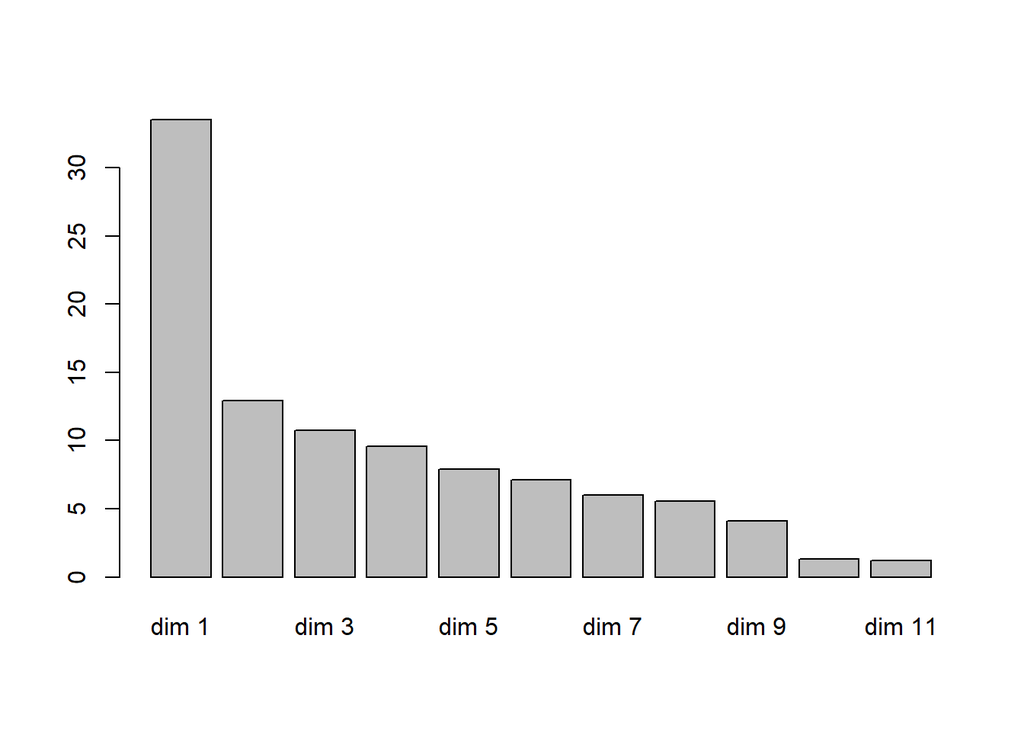

```r
barplot(acm$eig[,2])
```

On peut aussi montrer la variance expliquée cumulée.

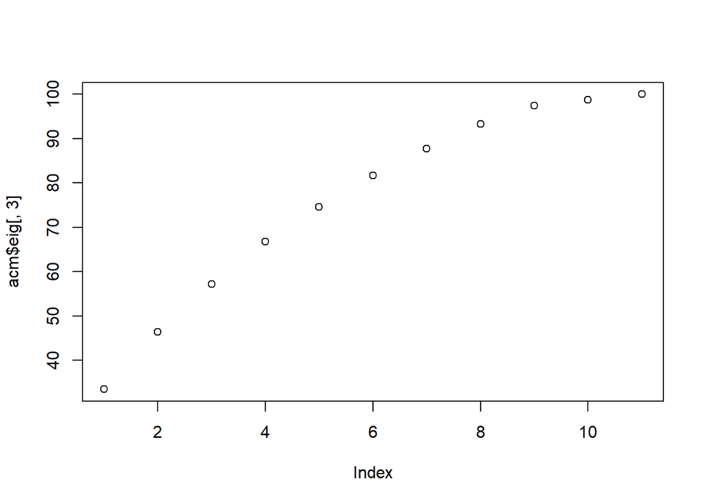

```r
plot(acm$eig[,3])
```

Mais aussi, et c’est important en ACM, le saut de variance expliquée entre deux composantes.

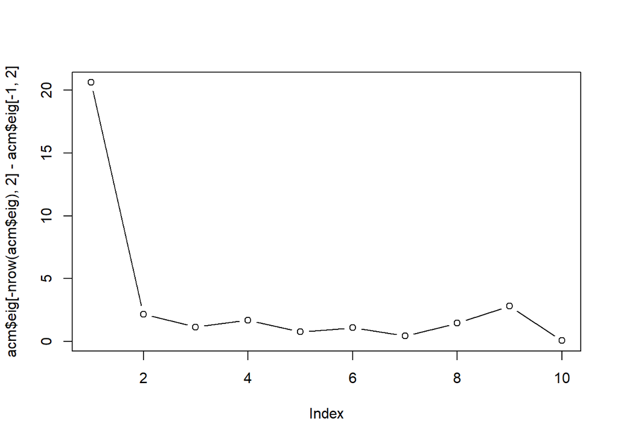

```r
plot(acm$eig[-nrow(acm$eig),2] - acm$eig[-1,2],type = "b")
```

*A faire* : représenter dans un même graphique les deux informations comme ci-dessous par exemple.

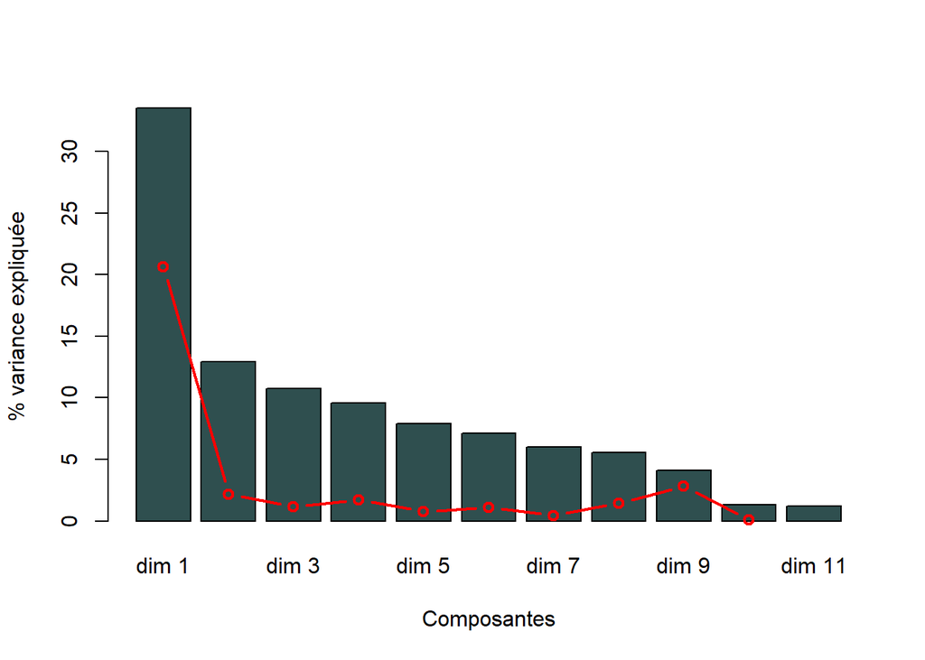

### Représentation graphique

#### Toutes les modalités

Par défaut, lorsqu’on utilise la fonction `plot()` sur l’objet obtenu, on obtient le *premier plan factoriel*, avec les 2 premières composantes. Les individus et les modalités sont représentées.

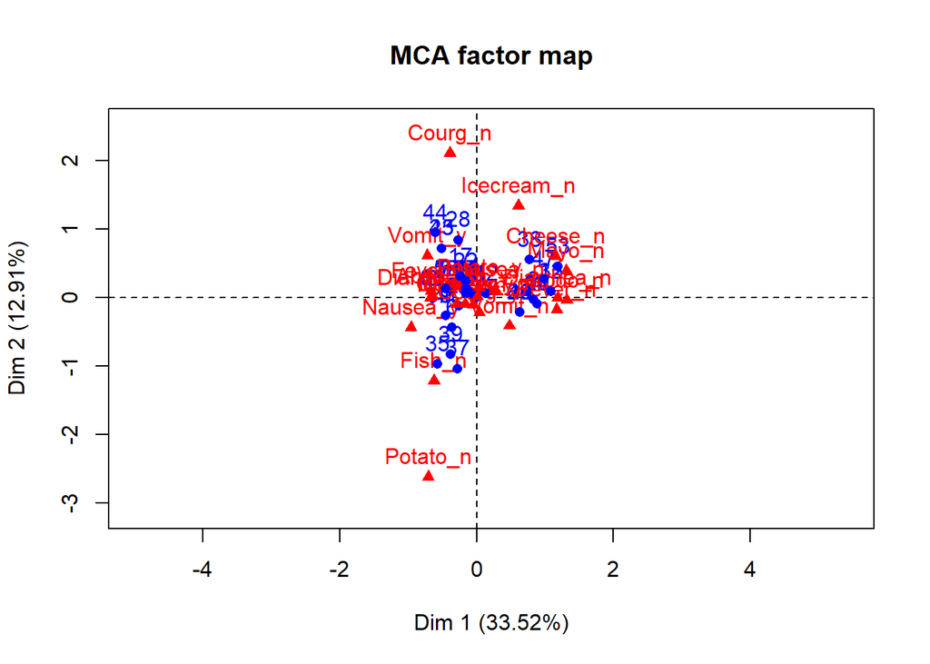

```r
plot(acm)
```

Si on veut choisir les composantes à représenter, nous utilisons le paramètre `axes`.

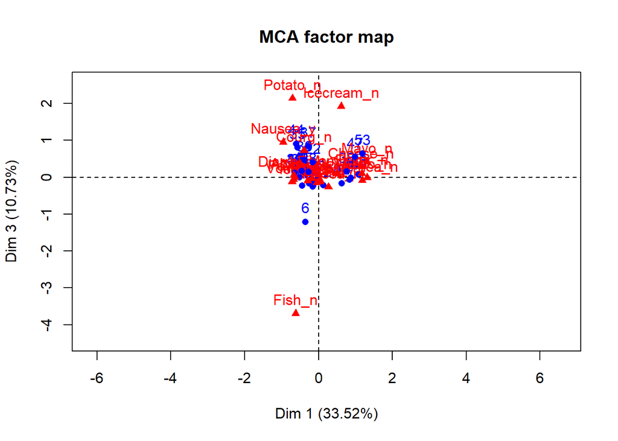

```r
plot(acm, axes = c(1, 3))
```

#### Individus uniquement

Pour n’avoir que les individus, il faut rendre invisible les modalités. Ce sont toujours les 2 premières composantes par défaut (et la syntaxe est la même pour changer les composantes).

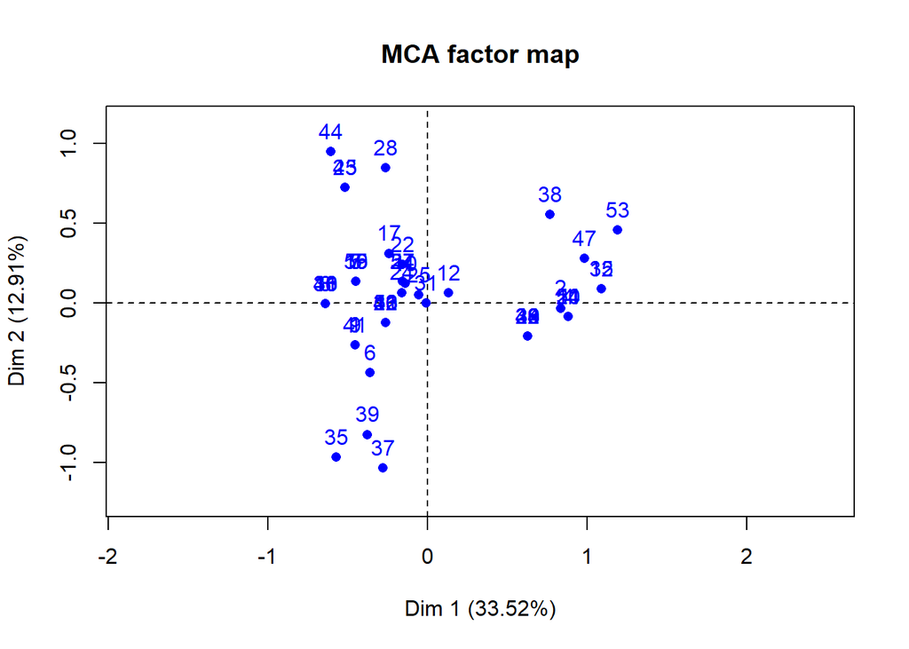

```r
plot(acm, invisible = "var")
```

#### Modalités uniquement

Et pour n’avoir que les modalités des variables, il faut rendre invisibles les individus

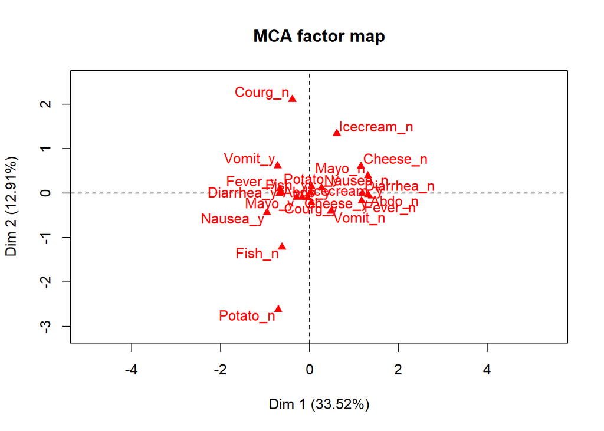

```r
plot(acm, invisible = "ind")
```

#### Variables

Il est aussi possible d’avoir une représentation des variables, chacune étant un *pseudo*-barycentre de ces modalités.

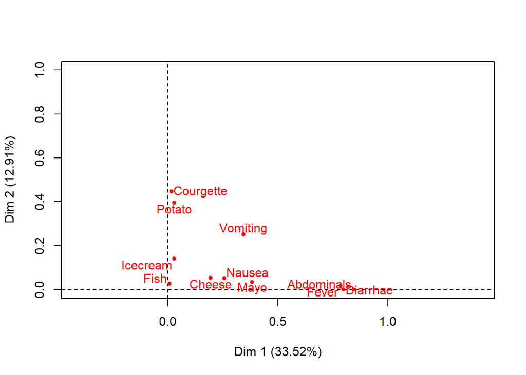

```r
plot(acm, choix = "var")
```

### Contributions et qualité de représentation

Il est possible d’obtenir la contribution de chaque modalité dans l’objet `contrib`, lui-même dans l’objet `var` du résultat de la fonction. Idem pour les individus (sous-objet `contrib` dans l’objet `ind`).

Pour la qualité de représentation, celle-ci est stockée dans le sous-objet `cos2` (de `ind` pour les individus et de `var` pour les modalités).

Ici, vu le nombre de modalités, il est possible de toutes les afficher pour mieux analyser.

```r
round(acm$var$contrib)
```

```
           Dim 1 Dim 2 Dim 3 Dim 4 Dim 5
Nausea_n       2     1     5     0     0
Nausea_y       5     3    17     0     2
Vomit_n        4     7     0     4     0
Vomit_y        6    11     1     6     0
Abdo_n        15     0     0     1     0
Abdo_y         8     0     0     0     0
Fever_n       14     1     0     1     0
Fever_y        8     0     0     1     0
Diarrhea_n    14     0     0     2     0
Diarrhea_y     8     0     0     1     0
Potato_n       1    26    21     1    12
Potato_y       0     2     1     0     1
Fish_n         0     2    21    53     0
Fish_y         0     0     0     1     0
Mayo_n         8     2     3     2     2
Mayo_y         2     0     1     1     0
Courg_n        0    29     4     1    13
Courg_y        0     3     0     0     1
Cheese_n       5     3     1     2    41
Cheese_y       1     0     0     0     6
Icecream_n     1     9    23    20    18
Icecream_y     0     1     2     2     1
```

```r
round(acm$var$cos2, 2)
```

```
           Dim 1 Dim 2 Dim 3 Dim 4 Dim 5
Nausea_n    0.26  0.05  0.25  0.00  0.02
Nausea_y    0.26  0.05  0.25  0.00  0.02
Vomit_n     0.34  0.25  0.01  0.11  0.00
Vomit_y     0.34  0.25  0.01  0.11  0.00
Abdo_n      0.85  0.00  0.00  0.01  0.00
Abdo_y      0.85  0.00  0.00  0.01  0.00
Fever_n     0.78  0.02  0.01  0.02  0.00
Fever_y     0.78  0.02  0.01  0.02  0.00
Diarrhea_n  0.80  0.00  0.00  0.03  0.01
Diarrhea_y  0.80  0.00  0.00  0.03  0.01
Potato_n    0.03  0.40  0.26  0.01  0.11
Potato_y    0.03  0.40  0.26  0.01  0.11
Fish_n      0.01  0.03  0.25  0.57  0.00
Fish_y      0.01  0.03  0.25  0.57  0.00
Mayo_n      0.38  0.03  0.04  0.03  0.02
Mayo_y      0.38  0.03  0.04  0.03  0.02
Courg_n     0.02  0.45  0.05  0.01  0.13
Courg_y     0.02  0.45  0.05  0.01  0.13
Cheese_n    0.19  0.05  0.01  0.02  0.41
Cheese_y    0.19  0.05  0.01  0.02  0.41
Icecream_n  0.03  0.14  0.29  0.23  0.17
Icecream_y  0.03  0.14  0.29  0.23  0.17
```

On fait de même pour les individus (*à tester*).

Mais il y a de plus une valeur test pour chaque modalité (sous-objet objet `v.test` de `var`), permettant de savoir si celle-ci est significativement éloigné du centre de gravité ou non (vrai si valeur absolue $>$ 2).

```r
round(acm$var$v.test,1)
```

```
           Dim 1 Dim 2 Dim 3 Dim 4 Dim 5
Nausea_n     3.7   1.7  -3.7   0.5   1.0
Nausea_y    -3.7  -1.7   3.7  -0.5  -1.0
Vomit_n      4.3  -3.7   0.8   2.5   0.5
Vomit_y     -4.3   3.7  -0.8  -2.5  -0.5
Abdo_n       6.8  -0.2   0.0  -0.8  -0.4
Abdo_y      -6.8   0.2   0.0   0.8   0.4
Fever_n      6.5  -1.0   0.5  -1.1  -0.1
Fever_y     -6.5   1.0  -0.5   1.1   0.1
Diarrhea_n   6.6   0.0  -0.5  -1.3  -0.6
Diarrhea_y  -6.6   0.0   0.5   1.3   0.6
Potato_n    -1.2  -4.6   3.8   0.7   2.4
Potato_y     1.2   4.6  -3.8  -0.7  -2.4
Fish_n      -0.6  -1.2  -3.7   5.6   0.2
Fish_y       0.6   1.2   3.7  -5.6  -0.2
Mayo_n       4.5   1.4   1.4   1.3  -1.1
Mayo_y      -4.5  -1.4  -1.4  -1.3   1.1
Courg_n     -0.9   4.9   1.7   0.8   2.6
Courg_y      0.9  -4.9  -1.7  -0.8  -2.6
Cheese_n     3.2   1.7   0.8   1.0   4.7
Cheese_y    -3.2  -1.7  -0.8  -1.0  -4.7
Icecream_n   1.3   2.8   3.9   3.5  -3.0
Icecream_y  -1.3  -2.8  -3.9  -3.5   3.0
```

### Interprétation

#### Nombre de composantes

Si nous regardons la variance cumulée, nous remarquons qu’avec 2 composantes, nous expliquons 46% de l’information, et 81% avec 6 axes (la moitié).

#### Axe 1

Le premier axe est relié aux modalités suivantes (toutes avec des valeurs tests absolues supérieures à 3):

- avec coordonnées positives : `Abdo_n`, `Diarrhea_n`, `Fever_n` et `Mayo_n` et das une moindre mesure `Cheese_n` ;
- avec coordonnées négatives : `Diarrhea_y`, `Fever_y`, `Abdo_y`, `Vomit_y` et `Nausea_y`.

```r
ct1 = acm$var$contrib %>%
  data.frame() %>%
  rownames_to_column(var = "mod") %>%
  transmute(modalite = mod, contribution = round(Dim.1, 1))
co1 = acm$var$coord %>%
  data.frame() %>%
  rownames_to_column(var = "mod") %>%
  transmute(modalite = mod, coordonnee = round(Dim.1, 1))
vt1 = acm$var$v.test %>%
  data.frame() %>%
  rownames_to_column(var = "mod") %>%
  transmute(modalite = mod, v.test = round(Dim.1, 1))
ax1 = ct1 %>% inner_join(co1) %>% inner_join(vt1)
ax1 %>%
  arrange(desc(contribution))
```

```
     modalite contribution coordonnee v.test
1      Abdo_n         15.4        1.3    6.8
2  Diarrhea_n         13.8        1.2    6.6
3     Fever_n         13.5        1.2    6.5
4      Mayo_n          8.5        1.3    4.5
5  Diarrhea_y          7.9       -0.7   -6.6
6     Fever_y          7.7       -0.7   -6.5
7      Abdo_y          7.5       -0.6   -6.8
8     Vomit_y          5.6       -0.7   -4.3
9    Nausea_y          5.4       -1.0   -3.7
10   Cheese_n          4.6        1.2    3.2
11    Vomit_n          3.7        0.5    4.3
12     Mayo_y          1.9       -0.3   -4.5
13   Nausea_n          1.5        0.3    3.7
14   Potato_n          0.7       -0.7   -1.2
15   Cheese_y          0.7       -0.2   -3.2
16 Icecream_n          0.7        0.6    1.3
17    Courg_n          0.4       -0.4   -0.9
18     Fish_n          0.2       -0.6   -0.6
19 Icecream_y          0.1        0.0   -1.3
20   Potato_y          0.0        0.0    1.2
21     Fish_y          0.0        0.0    0.6
22    Courg_y          0.0        0.0    0.9
```

Il oppose donc les enfants ayant des symptômes d’intoxication alimentaire, sur la gauche du graphique (valeurs négatives sur l’axe), contre ceux n’en présentant pas à droite (valeurs positives donc).

#### Autres axes

*A Faire* : si possible en automatisant le processus.

## FactoInvestigate

En plus du package `FactoMineR`, il existe le package [`FactoInvestigate`](http://factominer.free.fr/reporting/index_fr.html) qui permet de créer un rapport automatique pour l’interprétation d’un résultat d’une fonction de `FactoMineR` (ici, de `MCA()` donc).

Voila comment lancer la création du rapport.

```r
library(FactoInvestigate)
Investigate(acm, file = "Investigate-ACM.Rmd")
```

## Package `Factoshiny`

Dans le même état d’esprit, le package [`Factoshiny`](http://factominer.free.fr/graphs/factoshiny-fr.html) permet lui de lancer une application dans un navigateur web pour réaliser une analyse des résultats, ainsi que pour exporter des graphiques et récupérer des tableaux. Voici comment lancer l’application :

```r
library(Factoshiny)
MCAshiny(acm)
```

## A faire

Merci de produire un document `Rmarkdown` contenant l’ensemble du code et des commentaires.

### Continuer sur `poison`

Reprendre l’ACM ci-dessous en ajoutant donc les quatre premières variables de la table `poison` en variables illustratives.

### AirBnB à Paris

Le site [Inside AirBnB](http://insideairbnb.com/) met à disposition les informations sur les logements proposés sur le site [AirBnB](https://www.airbnb.fr/) dans différentes villes, et en particulier [Paris](http://insideairbnb.com/paris/). Nous allons uiliser les données du 2 septembre 2015 (fichier légèrement retravaillé).

```r
airbnb = read.table("airbnb-paris-2015-09-02.csv",
                    header = T, sep = ",", quote = '"')
```

|  | id | zipcode | latitude | longitude | property_type | room_type | accommodates | bathrooms | bedrooms | beds | bed_type | square_feet | price | weekly_price | monthly_price | security_deposit | cleaning_fee | guests_included | extra_people | TV | Cable.TV | Wireless.Internet | Kitchen | Buzzer.Wireless.Intercom | Heating | Washer | Smoke.Detector | Safety.Card | Essentials | … |
| --- | --- | --- | --- | --- | --- | --- | --- | --- | --- | --- | --- | --- | --- | --- | --- | --- | --- | --- | --- | --- | --- | --- | --- | --- | --- | --- | --- | --- | --- | --- |
| 1 | 4884907 | 75017 | 48.8772703805184 | 2.29693503057376 | Apartment | Private room | 2 | 1 | 1 | 1 | Pull-out Sofa |  | 45 | 470 | 1750 |  | 12 | 2 | 20 | True | True | True | True | True | True | True | True | True | True | … |
| 2 | 1225419 | 75017 | 48.8771686955447 | 2.29607284681835 | Apartment | Private room | 2 | 1 | 1 | 1 | Real Bed | 0 | 65 |  | 1200 | 500 | 50 | 1 | 30 | False | False | False | True | True | True | False | False | False | True | … |
| 3 | 2078827 | 75017 | 48.8764925159127 | 2.2964987451631 | Apartment | Entire home/apt | 2 | 1 | 1 | 1 | Real Bed |  | 79 | 480 | 1700 | 150 | 50 | 1 | 0 | True | False | True | True | False | True | True | False | False | True | … |
| 4 | 1691272 | 75017 | 48.8784291976012 | 2.29486937561361 | Bed &amp; Breakfast | Private room | 2 | 1 | 1 | 2 | Real Bed |  | 150 |  |  |  |  | 1 | 0 | True | False | False | False | False | True | False | False | False | False | … |
| 5 | 7385374 | 75017 | 48.8750359349875 | 2.29321506821092 | Apartment | Entire home/apt | 1 | 1 | 1 | 1 | Real Bed |  | 49 | 330 | 730 | 87 |  | 1 | 0 | True | False | True | True | False | True | False | False | False | True | … |
| 6 | 4296120 | 75008 | 48.8773843523485 | 2.29668403641196 | Apartment | Entire home/apt | 6 | 3 | 3 | 3 | Real Bed |  | 200 |  |  | 500 |  | 2 | 20 | True | True | True | True | True | True | True | False | True | True | … |
| 7 | 5542637 | 75017 | 48.8841423698228 | 2.32618068032104 | Apartment | Private room | 2 | 1 | 1 | 2 | Real Bed |  | 160 |  |  |  |  | 1 | 0 | False | False | False | False | False | False | False | False | False | False | … |
| 8 | 5000245 | 75017 | 48.8856971309268 | 2.32601718040676 | Apartment | Private room | 2 | 1 | 1 | 1 | Real Bed |  | 50 |  |  |  |  | 1 | 0 | True | True | True | True | True | True | False | False | False | False | … |
| 9 | 2050473 | 75017 | 48.8759565538174 | 2.29624928339413 | Apartment | Entire home/apt | 3 | 1 | 1 | 1 | Real Bed |  | 160 |  |  | 1000 | 60 | 2 | 20 | True | True | True | True | False | True | True | True | True | True | … |
| 10 | 4161209 | 75008 | 48.8763639295571 | 2.29661119514194 | Apartment | Entire home/apt | 2 | 1 | 1 | 1 | Real Bed |  | 95 | 600 | 1900 | 300 |  | 1 | 0 | True | True | True | True | True | True | True | False | False | True | … |

[output cut: 90 more lines]

Nous allons nous intéresser aux informations sur les équipements des logements (ensemble des variables binaires).

Vous devez donc réaliser les étapes suivantes :

- Décrire rapidement les données
- Réaliser une ACM et produire les graphiques nécessaires à l’interprétation
  - ne pas hésiter à ajouter des variables en illustratives
- Que peut-on dire globalement ?